# Preliminary descriptives for social isolation in E-Risk

# Missingness descriptives

## Frequency tables social isolation

### NAs per person

|  | Freq | % |
| --- | --- | --- |
| **0** | 2079 | 93.15 |
| **1** | 89 | 3.99 |
| **2** | 46 | 2.06 |
| **3** | 18 | 0.81 |
| **Total** | 2232 | 100.00 |

### Frequencies at age 5

|  | Freq | % Valid | % Total |
| --- | --- | --- | --- |
| **0** | 894 | 40.05 | 40.05 |
| **0.5** | 512 | 22.94 | 22.94 |
| **0.6** | 4 | 0.18 | 0.18 |
| **0.75** | 1 | 0.04 | 0.04 |
| **1** | 308 | 13.80 | 13.80 |
| **1.2** | 3 | 0.13 | 0.13 |
| **1.25** | 1 | 0.04 | 0.04 |
| **1.5** | 191 | 8.56 | 8.56 |
| **1.6** | 1 | 0.04 | 0.04 |
| **1.7** | 1 | 0.04 | 0.04 |
| **1.8** | 1 | 0.04 | 0.04 |
| **2** | 119 | 5.33 | 5.33 |
| **2.3** | 1 | 0.04 | 0.04 |
| **2.5** | 54 | 2.42 | 2.42 |
| **2.8** | 1 | 0.04 | 0.04 |
| **2.9** | 1 | 0.04 | 0.04 |
| **3** | 48 | 2.15 | 2.15 |
| **3.3** | 1 | 0.04 | 0.04 |
| **3.4** | 1 | 0.04 | 0.04 |
| **3.5** | 23 | 1.03 | 1.03 |
| **3.6** | 1 | 0.04 | 0.04 |
| **3.9** | 1 | 0.04 | 0.04 |
| **4** | 22 | 0.99 | 0.99 |
| **4.4** | 1 | 0.04 | 0.04 |
| **4.5** | 7 | 0.31 | 0.31 |
| **5** | 14 | 0.63 | 0.63 |
| **5.5** | 4 | 0.18 | 0.18 |
| **6** | 5 | 0.22 | 0.22 |
| **6.5** | 5 | 0.22 | 0.22 |
| **7** | 2 | 0.09 | 0.09 |
| **8** | 1 | 0.04 | 0.04 |
| **9** | 1 | 0.04 | 0.04 |
| **10** | 1 | 0.04 | 0.04 |
| **12** | 1 | 0.04 | 0.04 |
| **<NA>** | 0 |  | 0.00 |
| **Total** | 2232 | 100.00 | 100.00 |

Zero NAs at age 5.

### Frequencies at age 7

|  | Freq | % Valid | % Total |
| --- | --- | --- | --- |
| **0** | 912 | 41.87 | 40.86 |
| **0.5** | 451 | 20.71 | 20.21 |
| **0.6** | 3 | 0.14 | 0.13 |
| **1** | 308 | 14.14 | 13.80 |
| **1.1** | 2 | 0.09 | 0.09 |
| **1.2** | 1 | 0.05 | 0.04 |
| **1.5** | 169 | 7.76 | 7.57 |
| **2** | 111 | 5.10 | 4.97 |
| **2.2** | 2 | 0.09 | 0.09 |
| **2.5** | 73 | 3.35 | 3.27 |
| **2.6** | 1 | 0.05 | 0.04 |
| **3** | 49 | 2.25 | 2.20 |
| **3.5** | 25 | 1.15 | 1.12 |
| **3.7** | 1 | 0.05 | 0.04 |
| **4** | 21 | 0.96 | 0.94 |
| **4.4** | 1 | 0.05 | 0.04 |
| **4.5** | 11 | 0.51 | 0.49 |
| **5** | 15 | 0.69 | 0.67 |
| **5.5** | 3 | 0.14 | 0.13 |
| **6** | 6 | 0.28 | 0.27 |
| **6.5** | 1 | 0.05 | 0.04 |
| **6.6** | 1 | 0.05 | 0.04 |
| **7** | 4 | 0.18 | 0.18 |
| **7.5** | 2 | 0.09 | 0.09 |
| **8** | 3 | 0.14 | 0.13 |
| **9.5** | 2 | 0.09 | 0.09 |
| **<NA>** | 54 |  | 2.42 |
| **Total** | 2232 | 100.00 | 100.00 |

54 NAs at age 7.

### Frequencies at age 10

|  | Freq | % Valid | % Total |
| --- | --- | --- | --- |
| **0** | 843 | 39.43 | 37.77 |
| **0.5** | 440 | 20.58 | 19.71 |
| **0.6** | 5 | 0.23 | 0.22 |
| **1** | 300 | 14.03 | 13.44 |
| **1.1** | 1 | 0.05 | 0.04 |
| **1.2** | 2 | 0.09 | 0.09 |
| **1.5** | 139 | 6.50 | 6.23 |
| **2** | 139 | 6.50 | 6.23 |
| **2.5** | 65 | 3.04 | 2.91 |
| **2.6** | 1 | 0.05 | 0.04 |
| **2.7** | 1 | 0.05 | 0.04 |
| **3** | 68 | 3.18 | 3.05 |
| **3.2** | 2 | 0.09 | 0.09 |
| **3.5** | 44 | 2.06 | 1.97 |
| **3.6** | 1 | 0.05 | 0.04 |
| **4** | 22 | 1.03 | 0.99 |
| **4.5** | 19 | 0.89 | 0.85 |
| **5** | 15 | 0.70 | 0.67 |
| **5.5** | 5 | 0.23 | 0.22 |
| **6** | 10 | 0.47 | 0.45 |
| **6.4** | 1 | 0.05 | 0.04 |
| **6.6** | 1 | 0.05 | 0.04 |
| **7** | 5 | 0.23 | 0.22 |
| **7.3** | 1 | 0.05 | 0.04 |
| **7.5** | 3 | 0.14 | 0.13 |
| **7.9** | 1 | 0.05 | 0.04 |
| **8** | 1 | 0.05 | 0.04 |
| **9** | 1 | 0.05 | 0.04 |
| **10** | 1 | 0.05 | 0.04 |
| **11** | 1 | 0.05 | 0.04 |
| **<NA>** | 94 |  | 4.21 |
| **Total** | 2232 | 100.00 | 100.00 |

94 NAs at age 10.

### Frequencies at age 12

|  | Freq | % Valid | % Total |
| --- | --- | --- | --- |
| **0** | 922 | 42.98 | 41.31 |
| **0.5** | 358 | 16.69 | 16.04 |
| **0.6** | 6 | 0.28 | 0.27 |
| **0.75** | 3 | 0.14 | 0.13 |
| **1** | 294 | 13.71 | 13.17 |
| **1.1** | 2 | 0.09 | 0.09 |
| **1.2** | 4 | 0.19 | 0.18 |
| **1.25** | 1 | 0.05 | 0.04 |
| **1.5** | 139 | 6.48 | 6.23 |
| **1.7** | 2 | 0.09 | 0.09 |
| **1.75** | 2 | 0.09 | 0.09 |
| **1.8** | 5 | 0.23 | 0.22 |
| **2** | 147 | 6.85 | 6.59 |
| **2.5** | 56 | 2.61 | 2.51 |
| **2.7** | 1 | 0.05 | 0.04 |
| **2.75** | 1 | 0.05 | 0.04 |
| **2.9** | 1 | 0.05 | 0.04 |
| **3** | 63 | 2.94 | 2.82 |
| **3.5** | 31 | 1.45 | 1.39 |
| **3.75** | 1 | 0.05 | 0.04 |
| **4** | 33 | 1.54 | 1.48 |
| **4.5** | 13 | 0.61 | 0.58 |
| **4.9** | 1 | 0.05 | 0.04 |
| **5** | 13 | 0.61 | 0.58 |
| **5.2** | 1 | 0.05 | 0.04 |
| **5.4** | 1 | 0.05 | 0.04 |
| **5.5** | 11 | 0.51 | 0.49 |
| **5.6** | 1 | 0.05 | 0.04 |
| **6** | 16 | 0.75 | 0.72 |
| **6.5** | 5 | 0.23 | 0.22 |
| **7.5** | 2 | 0.09 | 0.09 |
| **8** | 1 | 0.05 | 0.04 |
| **9** | 3 | 0.14 | 0.13 |
| **10** | 4 | 0.19 | 0.18 |
| **11** | 1 | 0.05 | 0.04 |
| **<NA>** | 87 |  | 3.90 |
| **Total** | 2232 | 100.00 | 100.00 |

87 NAs at age 12.

## Groups for participants missing 2 or 3 time points

```r
# group with 18 missing 3 time points vs everyone else
dat <- dat %>%
  mutate(
    missing_3_time_points =
      if_else(
        na.per.person.si > 2,
        1,
        0) %>%
      recode_factor(
        "0" = "No",
        "1" = "Yes"
      )
  )

# create group of just 18 who have 3 missing time points
dat.18 <- filter(dat, missing_3_time_points == "Yes")

# excluding the 18 missing 3 time points, those with 2 missing time points vs every one else
dat.missing.3time <- filter(dat,
                      na.per.person.si != 3)

dat.missing.3time <- dat.missing.3time %>%
  mutate(
    missing_2_time_points =
      if_else(
        na.per.person.si > 1 & na.per.person.si < 3,
        1,
        0) %>%
      recode_factor(
        "0" = "No",
        "1" = "Yes"
      )
  )
```

# Differences for those who have missing social isolation data

Results from t-tests and Chi square tests assessing significant group differences for those who were missing three time points, and for those who were missing two time pionts. 46 people were missing two of the four time points. 18 people were missing three out of four time points.

## Social isolation at age 5

Social isolation at age five was not significantly different for those missing three time points, compared to everyone else (t =0.713, df=17.245, p=0.485). Mean for group **not** missing three time points = 0.815, mean for group missing three three time points = 0.611. Social isolation at age five was not significantly different for those missing two time points, compared to everyone else (t =-0.799, df=46.422, p=0.429). Mean for group **not** missing two time points = 0.811, mean for group missing two three time points = 0.967.

## Internalising problems at age 5

Internalising behaviours at age five was not significantly different for those missing three time points, compared to everyone else (t =-0.563, df=17.256, p=0.581). Mean for group **not** missing three time points = 6.87, mean for group missing three three time points = 7.505. Internalising behaviours at age five was not significantly different for those missing two time points, compared to everyone else (t =0.085, df=46.227, p=0.933). Mean for group **not** missing two time points = 6.871, mean for group missing two three time points = 6.799.

## Externalising problems at age 5

Externalising behaviours at age five was not significantly different for those missing three time points, compared to everyone else (t =0.361, df=17.289, p=0.723). Mean for group **not** missing three time points = 18.313, mean for group missing three three time points = 17.167. Externalising behaviours at age five was not significantly different for those missing two time points, compared to everyone else (t =-1.195, df=46.891, p=0.238). Mean for group **not** missing two time points = 18.262, mean for group missing two three time points = 20.724.

# Missingness differences at age 18

We found no differences between those who did and did not take part at age 18 in terms of socioeconomic status (SES) assessed when the cohort was initially defined (χ2 = 0.86, p = 0.65), age-5 IQ scores (t = 0.98, p = 0.33), or age-5 emotional or behavioural problems (t = 0.40, p = 0.69 and t = 0.41, p = 0.68, respectively). There were 2066 complete responses at age 18 (92.56% retention).

# Means across all time points

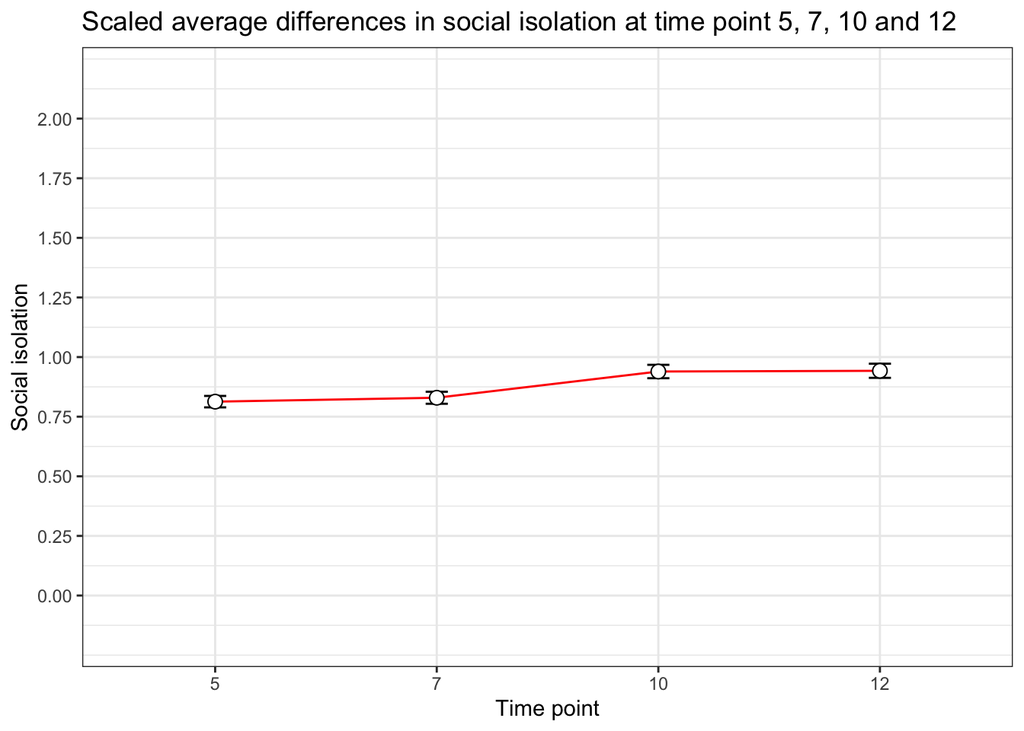

## Combined mother/teacher report of social isolation

|  | Age five | Age seven | Age ten | Age twelve |
| --- | --- | --- | --- | --- |
| **Mean** | 0.81 | 0.83 | 0.94 | 0.94 |
| **Std.Dev** | 1.13 | 1.18 | 1.30 | 1.37 |
| **Min** | 0.00 | 0.00 | 0.00 | 0.00 |
| **Max** | 12.00 | 9.50 | 11.00 | 11.00 |
| **Skewness** | 2.71 | 2.50 | 2.32 | 2.50 |
| **Kurtosis** | 12.00 | 8.84 | 7.54 | 8.76 |
| **N.Valid** | 2232.00 | 2178.00 | 2138.00 | 2145.00 |
| **Pct.Valid** | 100.00 | 97.58 | 95.79 | 96.10 |

## Mother report of social isolation

|  | Age five | Age seven | Age ten | Age twelve |
| --- | --- | --- | --- | --- |
| **Mean** | 0.97 | 0.98 | 1.10 | 1.05 |
| **Std.Dev** | 1.44 | 1.53 | 1.63 | 1.66 |
| **Min** | 0.00 | 0.00 | 0.00 | 0.00 |
| **Max** | 12.00 | 12.00 | 11.00 | 12.00 |
| **Skewness** | 2.17 | 2.31 | 2.22 | 2.31 |
| **Kurtosis** | 6.33 | 6.76 | 6.36 | 6.95 |
| **N.Valid** | 2230.00 | 2178.00 | 2138.00 | 2141.00 |
| **Pct.Valid** | 99.91 | 97.58 | 95.79 | 95.92 |

## Teacher report

|  | Age five | Age seven | Age ten | Age twelve |
| --- | --- | --- | --- | --- |
| **Mean** | 0.62 | 0.64 | 0.72 | 0.77 |
| **Std.Dev** | 1.25 | 1.31 | 1.46 | 1.49 |
| **Min** | 0.00 | 0.00 | 0.00 | 0.00 |
| **Max** | 12.00 | 10.00 | 12.00 | 12.00 |
| **Skewness** | 3.08 | 3.05 | 2.85 | 2.56 |
| **Kurtosis** | 13.16 | 11.56 | 9.76 | 7.71 |
| **N.Valid** | 2093.00 | 2026.00 | 1924.00 | 1775.00 |
| **Pct.Valid** | 93.77 | 90.77 | 86.20 | 79.53 |